# Bank Churn Prediction Project

### `Project 6: Bank Churn Prediction`

- Businesses like banks that provide service have to worry about the problem of 'Churn' i.e. customers leaving and joining another service provider. It is important to understand which aspects of the service influence a customer's decision in this regard. Management can concentrate efforts on the improvement of service, keeping in mind these priorities.

### `Objective:`

- Given a Bank customer, build a neural network-based classifier that can determine whether they will leave or not in the next 6 months.

### `Learning Outcomes:`

- Application of NN for classification

### `Domain`

- Banking

### `Datasets Information:`

The case study is from an open-source dataset from Kaggle. The dataset contains 10,000 sample points with 14 distinct features such as CustomerId, CreditScore, Geography, Gender, Age, Tenure, Balance, etc. Link to the Kaggle project site:https://www.kaggle.com/barelydedicated/bank-customer-churn-modeling

- RowNumber: Row number.
- CustomerId: Unique identification key for different customers.
- Surname: Surname of the customer
- Credit Score: Credit score is a measure of an individual's ability to pay back the borrowed amount. It is the numerical representation of their creditworthiness. A credit score is a 3-digit number that falls in the range of 300-900, 900 being the highest.
- Geography: The country to which the customer belongs.
- Gender: The gender of the customer.
- Age: Age of the customer.
- Tenure: The period of time a customer has been associated with the bank.
- Balance: The account balance (the amount of money deposited in the bank account) of the customer.
- NumOfProducts: How many accounts, bank account affiliated products the person has.
- HasCrCard: Does the customer have a credit card through the bank?
- IsActiveMember: Subjective, but for the concept
- EstimatedSalary: Estimated salary of the customer.
- Exited: Did they leave the bank after all?

### `Steps and tasks:`

- 1. Read the dataset
- 1. Drop the columns which are unique for all users like IDs (5 points)
- 1. Perform bivariate analysis and give your insights from the same (5 points)
- 1. Distinguish the feature and target set and divide the data set into training and test sets (5 points)
- 1. Normalize the train and test data (10points)
- 1. Initialize & build the model. Identify the points of improvement and implement the same. (20)
- 1. Predict the results using 0.5 as a threshold (10points)
- 1. Print the Accuracy score and confusion matrix (5 points)

## Deliverable 1. – Read the dataset

```python
# !pip install tensorflow==2.0
```

```python
import tensorflow as tf
print(tf.__version__)
```

```
2.3.1
```

```python
import pandas as pd                                   # import pandas
import numpy as np                                    # import numpy
%matplotlib inline
import seaborn as sns                                 # import seaborn library
import warnings
warnings.filterwarnings('ignore')
from sklearn.model_selection import train_test_split
import tensorflow as tf
from sklearn import preprocessing
from tensorflow.keras.models import Sequential
from tensorflow.keras.layers import Dense, Dropout, BatchNormalization
from sklearn.metrics import accuracy_score, confusion_matrix, precision_score, recall_score, f1_score, precision_recall_curve, auc
import matplotlib.pyplot as plt
from tensorflow.keras import optimizers
from sklearn.preprocessing import StandardScaler
from sklearn.metrics import confusion_matrix, accuracy_score
```

```python
# Import dataset
df = pd.read_csv('bank.csv')                          # read customer data
df.head()                                             # Display the dataframe
```

|  | RowNumber | CustomerId | Surname | CreditScore | Geography | Gender | Age | Tenure | Balance | NumOfProducts | HasCrCard | IsActiveMember | EstimatedSalary | Exited |
| --- | --- | --- | --- | --- | --- | --- | --- | --- | --- | --- | --- | --- | --- | --- |
| 0 | 1 | 15634602 | Hargrave | 619 | France | Female | 42 | 2 | 0.00 | 1 | 1 | 1 | 101348.88 | 1 |
| 1 | 2 | 15647311 | Hill | 608 | Spain | Female | 41 | 1 | 83807.86 | 1 | 0 | 1 | 112542.58 | 0 |
| 2 | 3 | 15619304 | Onio | 502 | France | Female | 42 | 8 | 159660.80 | 3 | 1 | 0 | 113931.57 | 1 |
| 3 | 4 | 15701354 | Boni | 699 | France | Female | 39 | 1 | 0.00 | 2 | 0 | 0 | 93826.63 | 0 |
| 4 | 5 | 15737888 | Mitchell | 850 | Spain | Female | 43 | 2 | 125510.82 | 1 | 1 | 1 | 79084.10 | 0 |

```python
# check datatype
df.info()
```

```
<class 'pandas.core.frame.DataFrame'>
RangeIndex: 10000 entries, 0 to 9999
Data columns (total 14 columns):
 #   Column           Non-Null Count  Dtype
---  ------           --------------  -----
 0   RowNumber        10000 non-null  int64
 1   CustomerId       10000 non-null  int64
 2   Surname          10000 non-null  object
 3   CreditScore      10000 non-null  int64
 4   Geography        10000 non-null  object
 5   Gender           10000 non-null  object
 6   Age              10000 non-null  int64
 7   Tenure           10000 non-null  int64
 8   Balance          10000 non-null  float64
 9   NumOfProducts    10000 non-null  int64
 10  HasCrCard        10000 non-null  int64
 11  IsActiveMember   10000 non-null  int64
 12  EstimatedSalary  10000 non-null  float64
 13  Exited           10000 non-null  int64
dtypes: float64(2), int64(9), object(3)
memory usage: 1.1+ MB
```

```python
# Check Shape
df.shape
```

```
(10000, 14)
```

```python
# Check Null Values
df.isnull().sum()
```

```
RowNumber          0
CustomerId         0
Surname            0
CreditScore        0
Geography          0
Gender             0
Age                0
Tenure             0
Balance            0
NumOfProducts      0
HasCrCard          0
IsActiveMember     0
EstimatedSalary    0
Exited             0
dtype: int64
```

```python
# Drop Duplicate Records if any
df.drop_duplicates()
```

|  | RowNumber | CustomerId | Surname | CreditScore | Geography | Gender | Age | Tenure | Balance | NumOfProducts | HasCrCard | IsActiveMember | EstimatedSalary | Exited |
| --- | --- | --- | --- | --- | --- | --- | --- | --- | --- | --- | --- | --- | --- | --- |
| 0 | 1 | 15634602 | Hargrave | 619 | France | Female | 42 | 2 | 0.00 | 1 | 1 | 1 | 101348.88 | 1 |
| 1 | 2 | 15647311 | Hill | 608 | Spain | Female | 41 | 1 | 83807.86 | 1 | 0 | 1 | 112542.58 | 0 |
| 2 | 3 | 15619304 | Onio | 502 | France | Female | 42 | 8 | 159660.80 | 3 | 1 | 0 | 113931.57 | 1 |
| 3 | 4 | 15701354 | Boni | 699 | France | Female | 39 | 1 | 0.00 | 2 | 0 | 0 | 93826.63 | 0 |
| 4 | 5 | 15737888 | Mitchell | 850 | Spain | Female | 43 | 2 | 125510.82 | 1 | 1 | 1 | 79084.10 | 0 |
| ... | ... | ... | ... | ... | ... | ... | ... | ... | ... | ... | ... | ... | ... | ... |
| 9995 | 9996 | 15606229 | Obijiaku | 771 | France | Male | 39 | 5 | 0.00 | 2 | 1 | 0 | 96270.64 | 0 |
| 9996 | 9997 | 15569892 | Johnstone | 516 | France | Male | 35 | 10 | 57369.61 | 1 | 1 | 1 | 101699.77 | 0 |
| 9997 | 9998 | 15584532 | Liu | 709 | France | Female | 36 | 7 | 0.00 | 1 | 0 | 1 | 42085.58 | 1 |
| 9998 | 9999 | 15682355 | Sabbatini | 772 | Germany | Male | 42 | 3 | 75075.31 | 2 | 1 | 0 | 92888.52 | 1 |
| 9999 | 10000 | 15628319 | Walker | 792 | France | Female | 28 | 4 | 130142.79 | 1 | 1 | 0 | 38190.78 | 0 |

10000 rows × 14 columns

## Deliverable 2. – Drop Unique Columns (5 points)

```python
# The unique columns include: Customer ID, Surname, RowNumber
df1 = df.drop(["RowNumber","CustomerId","Surname"], axis = 1)
df1.head()
```

|  | CreditScore | Geography | Gender | Age | Tenure | Balance | NumOfProducts | HasCrCard | IsActiveMember | EstimatedSalary | Exited |
| --- | --- | --- | --- | --- | --- | --- | --- | --- | --- | --- | --- |
| 0 | 619 | France | Female | 42 | 2 | 0.00 | 1 | 1 | 1 | 101348.88 | 1 |
| 1 | 608 | Spain | Female | 41 | 1 | 83807.86 | 1 | 0 | 1 | 112542.58 | 0 |
| 2 | 502 | France | Female | 42 | 8 | 159660.80 | 3 | 1 | 0 | 113931.57 | 1 |
| 3 | 699 | France | Female | 39 | 1 | 0.00 | 2 | 0 | 0 | 93826.63 | 0 |
| 4 | 850 | Spain | Female | 43 | 2 | 125510.82 | 1 | 1 | 1 | 79084.10 | 0 |

```python
print('Count of unique value in each column :')
df1.nunique()
```

```
Count of unique value in each column :
```

```
CreditScore         460
Geography             3
Gender                2
Age                  70
Tenure               11
Balance            6382
NumOfProducts         4
HasCrCard             2
IsActiveMember        2
EstimatedSalary    9999
Exited                2
dtype: int64
```

### Insight:

- There are still catagorical data, Geography and Gender, Tenure, NumofProducts, HasCrCard IsActiveMember, Exited
- But Each only have 2-4 categories, and tenure has 11
- There are also numerical features, suc as credit score, age and estimated salary

## Deliverable 3. – Perform bivariate analysis and give your insights from the same (5 points)

#### Note: I decided not to do one-hot encodeing before the bivariate analysis

## Univariate Analysis

```python
print('Value counts of all categorical columns:')
List = ['Geography', 'Gender', 'Tenure', 'NumOfProducts', 'HasCrCard','IsActiveMember','Exited']
for x in List:
    print(df1.groupby(x)[x].count())                                 # count categorical columns
```

```
Value counts of all categorical columns:
Geography
France     5014
Germany    2509
Spain      2477
Name: Geography, dtype: int64
Gender
Female    4543
Male      5457
Name: Gender, dtype: int64
Tenure
0      413
1     1035
2     1048
3     1009
4      989
5     1012
6      967
7     1028
8     1025
9      984
10     490
Name: Tenure, dtype: int64
NumOfProducts
1    5084
2    4590
3     266
4      60
Name: NumOfProducts, dtype: int64
HasCrCard
0    2945
1    7055
Name: HasCrCard, dtype: int64
IsActiveMember
0    4849
1    5151
Name: IsActiveMember, dtype: int64
Exited
0    7963
1    2037
Name: Exited, dtype: int64
```

```python
for x in List:
    print(df1[x].value_counts(normalize=True))                       # count percentage of the categorical columns
```

```
France     0.5014
Germany    0.2509
Spain      0.2477
Name: Geography, dtype: float64
Male      0.5457
Female    0.4543
Name: Gender, dtype: float64
2     0.1048
1     0.1035
7     0.1028
8     0.1025
5     0.1012
3     0.1009
4     0.0989
9     0.0984
6     0.0967
10    0.0490
0     0.0413
Name: Tenure, dtype: float64
1    0.5084
2    0.4590
3    0.0266
4    0.0060
Name: NumOfProducts, dtype: float64
1    0.7055
0    0.2945
Name: HasCrCard, dtype: float64
1    0.5151
0    0.4849
Name: IsActiveMember, dtype: float64
0    0.7963
1    0.2037
Name: Exited, dtype: float64
```

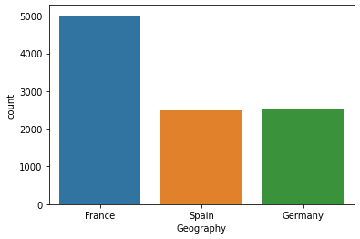

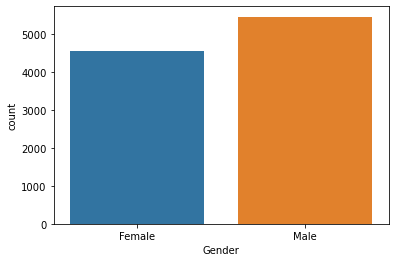

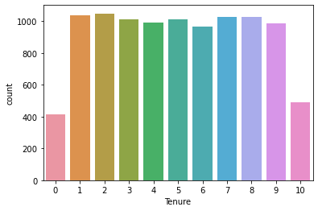

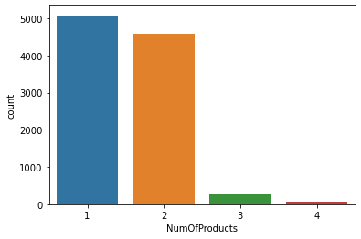

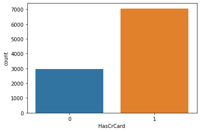

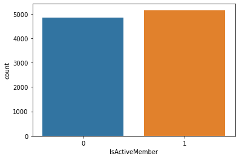

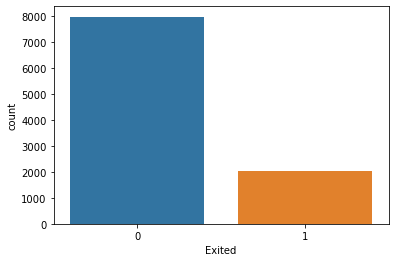

```python
for x in List:
    sns.countplot(df[x])
    plt.show()
```

```python
# Describe data
df1.describe().transpose()
```

|  | count | mean | std | min | 25% | 50% | 75% | max |
| --- | --- | --- | --- | --- | --- | --- | --- | --- |
| CreditScore | 10000.0 | 650.528800 | 96.653299 | 350.00 | 584.00 | 652.000 | 718.0000 | 850.00 |
| Age | 10000.0 | 38.921800 | 10.487806 | 18.00 | 32.00 | 37.000 | 44.0000 | 92.00 |
| Tenure | 10000.0 | 5.012800 | 2.892174 | 0.00 | 3.00 | 5.000 | 7.0000 | 10.00 |
| Balance | 10000.0 | 76485.889288 | 62397.405202 | 0.00 | 0.00 | 97198.540 | 127644.2400 | 250898.09 |
| NumOfProducts | 10000.0 | 1.530200 | 0.581654 | 1.00 | 1.00 | 1.000 | 2.0000 | 4.00 |
| HasCrCard | 10000.0 | 0.705500 | 0.455840 | 0.00 | 0.00 | 1.000 | 1.0000 | 1.00 |
| IsActiveMember | 10000.0 | 0.515100 | 0.499797 | 0.00 | 0.00 | 1.000 | 1.0000 | 1.00 |
| EstimatedSalary | 10000.0 | 100090.239881 | 57510.492818 | 11.58 | 51002.11 | 100193.915 | 149388.2475 | 199992.48 |
| Exited | 10000.0 | 0.203700 | 0.402769 | 0.00 | 0.00 | 0.000 | 0.0000 | 1.00 |

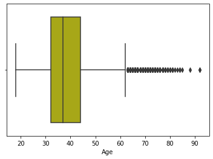

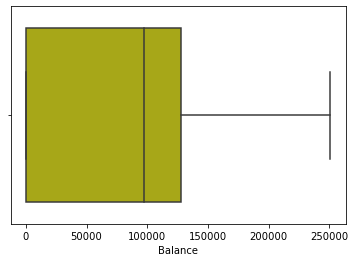

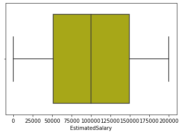

```python
# Show Box Plots for numercial features
List2 = ['Age', 'Balance', 'EstimatedSalary']
for x in List2:
    sns.boxplot(df1[x], color ='y')
    plt.show()
```

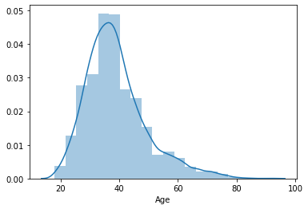

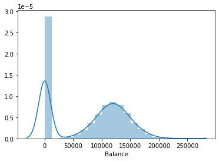

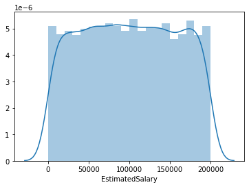

```python
for x in List2:
    sns.distplot(df1[x], bins = 20)
    plt.show()
```

### Insight:

- There are outliers for credit score, age. But should keep

## Bivariate Analysis

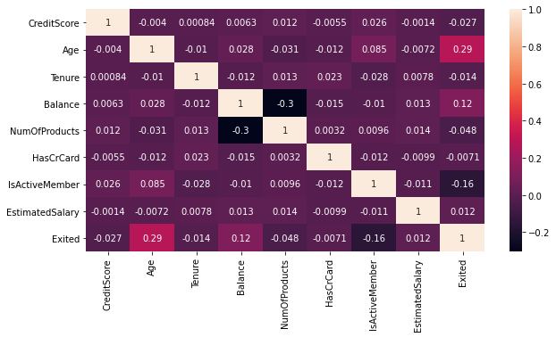

```python
plt.figure(figsize=(10,5))
sns.heatmap(df1.corr(), annot=True)  # heatmap
plt.show()
```

### Insight:

- Exited and Age have a positive correlation
- Balance and NumofProducts have negative correlation
- Others can be ignored

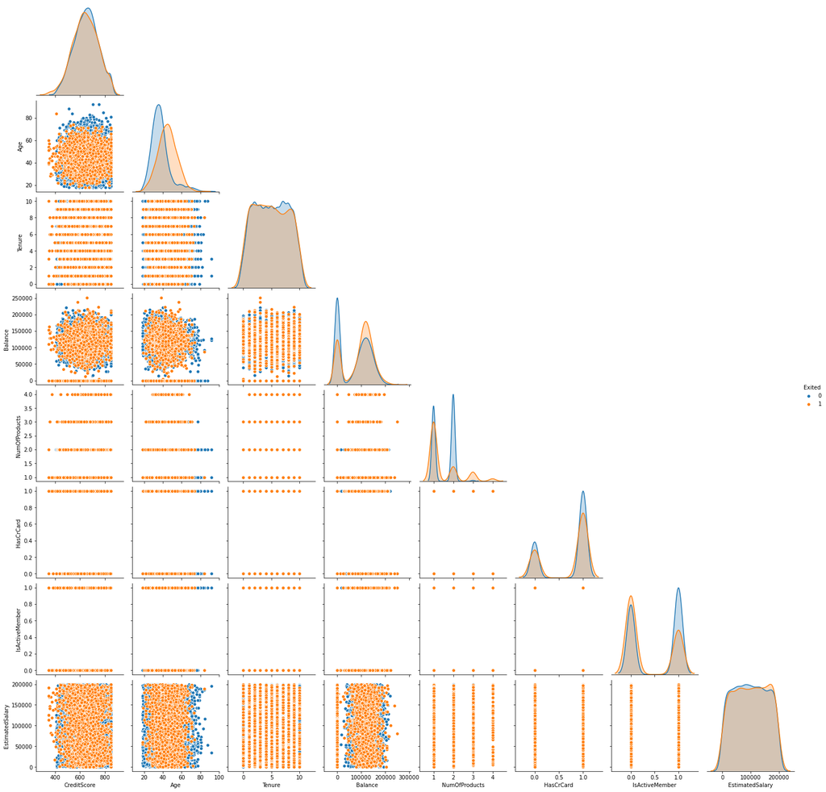

```python
# Visualize the correlations and potential number of clusters using the pair plot
sns.pairplot(df1,diag_kind='kde', hue='Exited', corner = True)
```

### Insight:

- No obevious trends between pairs.
- Diagnoal plots showed the Age, Balance, NumofProducts, HasCrCard, Isactive play roles on Exited

```python
List1 = df1.select_dtypes(include=['int64','float64']).columns.tolist()
List1
```

```
['CreditScore',
 'Age',
 'Tenure',
 'Balance',
 'NumOfProducts',
 'HasCrCard',
 'IsActiveMember',
 'EstimatedSalary',
 'Exited']
```

```python
df1[List1].groupby(['Exited']).mean()                       # Check status and relation for value columns
```

| Exited | CreditScore | Age | Tenure | Balance | NumOfProducts | HasCrCard | IsActiveMember | EstimatedSalary |
| --- | --- | --- | --- | --- | --- | --- | --- | --- |
| 0 | 651.853196 | 37.408389 | 5.033279 | 72745.296779 | 1.544267 | 0.707146 | 0.554565 | 99738.391772 |
| 1 | 645.351497 | 44.837997 | 4.932744 | 91108.539337 | 1.475209 | 0.699067 | 0.360825 | 101465.677531 |

```python
df1[List1].groupby(['Exited']).median()                       # Check status and relation for value columns
```

| Exited | CreditScore | Age | Tenure | Balance | NumOfProducts | HasCrCard | IsActiveMember | EstimatedSalary |
| --- | --- | --- | --- | --- | --- | --- | --- | --- |
| 0 | 653 | 36 | 5 | 92072.68 | 2 | 1 | 1 | 99645.04 |
| 1 | 646 | 45 | 5 | 109349.29 | 1 | 1 | 0 | 102460.84 |

### Insight:

```python
for x in List:
    print(pd.crosstab(df1[x],df1['Exited'],normalize='columns'))  # Check status for categorical columns
```

```
Exited            0         1
Geography
France     0.527942  0.397644
Germany    0.212859  0.399607
Spain      0.259199  0.202749
Exited         0         1
Gender
Female  0.427477  0.559156
Male    0.572523  0.440844
Exited         0         1
Tenure
0       0.039935  0.046637
1       0.100841  0.113893
2       0.106367  0.098675
3       0.099962  0.104566
4       0.098707  0.099656
5       0.100841  0.102602
6       0.096823  0.096220
7       0.106869  0.086892
8       0.103981  0.096711
9       0.096823  0.104566
10      0.048851  0.049583
Exited                0         1
NumOfProducts
1              0.461509  0.691703
2              0.532714  0.170839
3              0.005777  0.108002
4              0.000000  0.029455
Exited            0         1
HasCrCard
0          0.292854  0.300933
1          0.707146  0.699067
Exited                 0         1
IsActiveMember
0               0.445435  0.639175
1               0.554565  0.360825
Exited    0    1
Exited
0       1.0  0.0
1       0.0  1.0
```

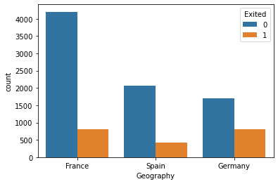

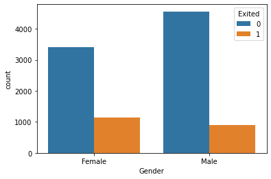

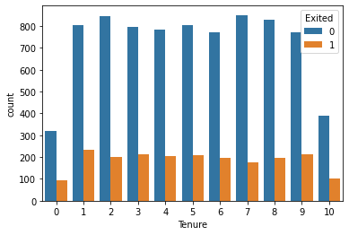

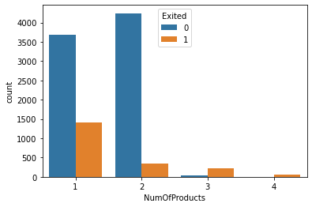

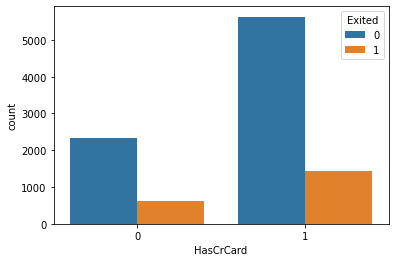

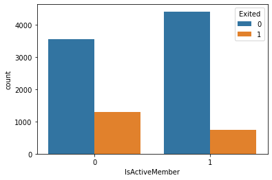

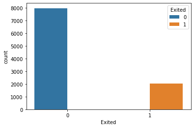

```python
for x in List:
    sns.countplot(df1[x], hue = df['Exited'])
    plt.show()
```

### Insight:

- Less french and spanish exited, more gemany exited
- More female exited than man
- More people with only 1 product exited

## Deliverable 4. – Distinguish the feature and target set and divide the data set into training and test sets (5 points)

```python
#creating dummy variables for the categorical features
df2 = pd.get_dummies(df1)
df2 = df2.astype('float32')
df2
```

|  | CreditScore | Age | Tenure | Balance | NumOfProducts | HasCrCard | IsActiveMember | EstimatedSalary | Exited | Geography_France | Geography_Germany | Geography_Spain | Gender_Female | Gender_Male |
| --- | --- | --- | --- | --- | --- | --- | --- | --- | --- | --- | --- | --- | --- | --- |
| 0 | 619.0 | 42.0 | 2.0 | 0.000000 | 1.0 | 1.0 | 1.0 | 101348.882812 | 1.0 | 1.0 | 0.0 | 0.0 | 1.0 | 0.0 |
| 1 | 608.0 | 41.0 | 1.0 | 83807.859375 | 1.0 | 0.0 | 1.0 | 112542.578125 | 0.0 | 0.0 | 0.0 | 1.0 | 1.0 | 0.0 |
| 2 | 502.0 | 42.0 | 8.0 | 159660.796875 | 3.0 | 1.0 | 0.0 | 113931.570312 | 1.0 | 1.0 | 0.0 | 0.0 | 1.0 | 0.0 |
| 3 | 699.0 | 39.0 | 1.0 | 0.000000 | 2.0 | 0.0 | 0.0 | 93826.632812 | 0.0 | 1.0 | 0.0 | 0.0 | 1.0 | 0.0 |
| 4 | 850.0 | 43.0 | 2.0 | 125510.820312 | 1.0 | 1.0 | 1.0 | 79084.101562 | 0.0 | 0.0 | 0.0 | 1.0 | 1.0 | 0.0 |
| ... | ... | ... | ... | ... | ... | ... | ... | ... | ... | ... | ... | ... | ... | ... |
| 9995 | 771.0 | 39.0 | 5.0 | 0.000000 | 2.0 | 1.0 | 0.0 | 96270.640625 | 0.0 | 1.0 | 0.0 | 0.0 | 0.0 | 1.0 |
| 9996 | 516.0 | 35.0 | 10.0 | 57369.609375 | 1.0 | 1.0 | 1.0 | 101699.773438 | 0.0 | 1.0 | 0.0 | 0.0 | 0.0 | 1.0 |
| 9997 | 709.0 | 36.0 | 7.0 | 0.000000 | 1.0 | 0.0 | 1.0 | 42085.578125 | 1.0 | 1.0 | 0.0 | 0.0 | 1.0 | 0.0 |
| 9998 | 772.0 | 42.0 | 3.0 | 75075.312500 | 2.0 | 1.0 | 0.0 | 92888.523438 | 1.0 | 0.0 | 1.0 | 0.0 | 0.0 | 1.0 |
| 9999 | 792.0 | 28.0 | 4.0 | 130142.789062 | 1.0 | 1.0 | 0.0 | 38190.781250 | 0.0 | 1.0 | 0.0 | 0.0 | 1.0 | 0.0 |

10000 rows × 14 columns

```python
x = df2.drop('Exited',axis=1)     # Feature columns
y = df2['Exited']                 # Prediction (1=True, 0=False)

x_train, x_test, y_train, y_test = train_test_split(x, y, test_size=0.2, random_state=7)

x_train
```

|  | CreditScore | Age | Tenure | Balance | NumOfProducts | HasCrCard | IsActiveMember | EstimatedSalary | Geography_France | Geography_Germany | Geography_Spain | Gender_Female | Gender_Male |
| --- | --- | --- | --- | --- | --- | --- | --- | --- | --- | --- | --- | --- | --- |
| 4989 | 629.0 | 40.0 | 9.0 | 0.000000 | 1.0 | 1.0 | 0.0 | 106.669998 | 1.0 | 0.0 | 0.0 | 0.0 | 1.0 |
| 4498 | 570.0 | 30.0 | 2.0 | 131406.562500 | 1.0 | 1.0 | 1.0 | 47952.449219 | 1.0 | 0.0 | 0.0 | 0.0 | 1.0 |
| 8876 | 556.0 | 46.0 | 3.0 | 131764.953125 | 1.0 | 1.0 | 1.0 | 108500.656250 | 0.0 | 0.0 | 1.0 | 0.0 | 1.0 |
| 670 | 624.0 | 48.0 | 3.0 | 122388.382812 | 2.0 | 0.0 | 0.0 | 30020.089844 | 0.0 | 1.0 | 0.0 | 1.0 | 0.0 |
| 9552 | 664.0 | 41.0 | 5.0 | 0.000000 | 1.0 | 1.0 | 1.0 | 152054.328125 | 1.0 | 0.0 | 0.0 | 1.0 | 0.0 |
| ... | ... | ... | ... | ... | ... | ... | ... | ... | ... | ... | ... | ... | ... |
| 919 | 552.0 | 45.0 | 9.0 | 0.000000 | 2.0 | 1.0 | 0.0 | 26752.560547 | 0.0 | 0.0 | 1.0 | 0.0 | 1.0 |
| 4307 | 770.0 | 46.0 | 9.0 | 190678.015625 | 1.0 | 1.0 | 1.0 | 14725.360352 | 0.0 | 0.0 | 1.0 | 0.0 | 1.0 |
| 5699 | 684.0 | 35.0 | 6.0 | 135871.500000 | 1.0 | 1.0 | 1.0 | 87219.406250 | 1.0 | 0.0 | 0.0 | 0.0 | 1.0 |
| 537 | 686.0 | 34.0 | 9.0 | 0.000000 | 2.0 | 1.0 | 0.0 | 127569.796875 | 0.0 | 0.0 | 1.0 | 0.0 | 1.0 |
| 9412 | 725.0 | 26.0 | 6.0 | 98684.148438 | 1.0 | 0.0 | 0.0 | 133720.562500 | 1.0 | 0.0 | 0.0 | 0.0 | 1.0 |

8000 rows × 13 columns

```python
x_test.shape
```

```
(2000, 13)
```

## Deliverable 5. – Normalize the train and test data (10points)

```python
# x_train = preprocessing.normalize(x_train)
# x_test = preprocessing.normalize(x_test)
```

```python
sc = StandardScaler()
x_train = sc.fit_transform(x_train)
x_test = sc.transform(x_test)
print(x_train)
```

[output not shown]

```python
x_train.shape
```

```
(8000, 13)
```

```python
x_test.shape
```

```
(2000, 13)
```

```python
y_train.shape
```

```
(8000,)
```

```python
y_test.shape
```

```
(2000,)
```

## Deliverable 6. – Initialize & build the model. Identify the points of improvement and implement the same. (20)

```python
model = Sequential()                                                                 # create sequential model using keras
model.add(Dense(20, input_shape = (13,), activation = 'relu'))                       # Add layers
model.add(Dense(20, activation = 'relu'))
model.add(Dense(20, activation = 'relu'))
model.add(Dense(1, activation = 'sigmoid'))
sgd = optimizers.Adam(lr = 0.001)                                                     # choose optimizer
model.compile(optimizer = sgd, loss = 'binary_crossentropy', metrics=['accuracy'])    # model compile
model.summary()                                                                       # model summary
```

```
Model: "sequential_7"
_________________________________________________________________
Layer (type)                 Output Shape              Param #
=================================================================
dense_28 (Dense)             (None, 20)                280
_________________________________________________________________
dense_29 (Dense)             (None, 20)                420
_________________________________________________________________
dense_30 (Dense)             (None, 20)                420
_________________________________________________________________
dense_31 (Dense)             (None, 1)                 21
=================================================================
Total params: 1,141
Trainable params: 1,141
Non-trainable params: 0
_________________________________________________________________
```

```python
history = model.fit(x_train, y_train.values, batch_size = 500, epochs = 300, verbose = 1)
```

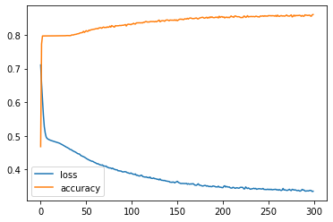

```python
hist  = pd.DataFrame(history.history)
hist['epoch'] = history.epoch
import matplotlib.pyplot as plt

plt.plot(hist['loss'])
plt.plot(hist['accuracy'])
plt.legend(("loss","accuracy" ) , loc =0)
```

```python
results = model.evaluate(x_test, y_test.values)   # Evaluate Test Results
```

```python
print(model.metrics_names)                        #  Printed Results
print(results)
```

```
['loss', 'accuracy']
[0.38504499197006226, 0.8504999876022339]
```

## Deliverable – 7. Predict the results using 0.5 as a threshold (10points)

```python
y_pred = model.predict(x_test,batch_size=200, verbose=0)
y_pred
```

```
array([[0.5175059 ],
       [0.18026453],
       [0.02416936],
       ...,
       [0.07600757],
       [0.25120443],
       [0.15670034]], dtype=float32)
```

```python
# model predictions are numbers
```

```python
# set threshole
y_pred_05 = (y_pred > 0.5)
y_pred_x = y_pred_05.astype(int)
```

```python
df4 = pd.DataFrame(y_test)
df4['predicted'] =y_pred_x
df4
```

|  | Exited | predicted |
| --- | --- | --- |
| 1977 | 1.0 | 1 |
| 3880 | 0.0 | 0 |
| 52 | 0.0 | 0 |
| 2551 | 0.0 | 1 |
| 2246 | 0.0 | 0 |
| ... | ... | ... |
| 9505 | 0.0 | 0 |
| 2836 | 0.0 | 0 |
| 1169 | 0.0 | 0 |
| 9929 | 0.0 | 0 |
| 8486 | 1.0 | 0 |

2000 rows × 2 columns

## Deliverable – 8. Print the Accuracy score and confusion matrix (5 points)

```python
# without 0.5 as threshole
y_pred_cls = model.predict_classes(x_test, batch_size=200, verbose=0)
print('Accuracy Model1 (Dropout): '+ str(model.evaluate(x_test,y_test.values)[1]))
print('Recall_score: ' + str(recall_score(y_test.values,y_pred_cls)))
print('Precision_score: ' + str(precision_score(y_test.values, y_pred_cls)))
print('F-score: ' + str(f1_score(y_test.values,y_pred_cls)))
confusion_matrix(y_test.values, y_pred_cls)
```

```
Accuracy Model1 (Dropout): 0.8504999876022339
Recall_score: 0.44038929440389296
Precision_score: 0.724
F-score: 0.5476550680786687
```

```
array([[1520,   69],
       [ 230,  181]], dtype=int64)
```

```python
print('Threshold 0.5 case:')
cm_05 = confusion_matrix(y_test, y_pred_x)
print(cm_05)
accuracy_score(y_test, y_pred_x)
```

```
Threshold 0.5 case:
[[1520   69]
 [ 230  181]]
```

```
0.8505
```

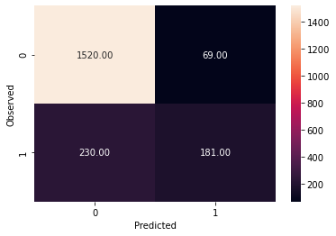

```python
sns.heatmap(cm_05, annot=True,  fmt='.2f', xticklabels = [0,1] , yticklabels = [0,1] )  # Plot confusion matrix as heat map
plt.ylabel('Observed')
plt.xlabel('Predicted')
plt.show()
```